# Data Science on Digital Ocean (Part 1)

I teach Introduction to Data Science at a major public university. At the beginning of each semester I tell my students that they will be shocked at what I don’t know about statistics, which is a roundabout way of telling them that a *lot* of data science has little to do with data or science.

(I also tell them that A Data Scientist is a statistician after you remove reason and accountability. Most of my students are biostatisticians. It pays to know your audience.)

About half of what the course covers is the technologies around data science. The story I tell is that I want students to be able to reproduce a specific result from a specific moment in their data analysis, even if they need to do it years later. Docker, git and Make therefor constitute the main part of that side of the course.

Despite the fact that the university provides infrastructure for us to run docker containers and the fact that my own students all have laptops of one sort or another, almost everyone struggles with their infrastructure. Getting Docker running on Windows is a common problem and this year, with the introduction of Apple Silicon, getting a development environment going on a Mac has proven difficult for many students as well.

And even if all those technical hurdles are lept, students may eventually want to move beyond either the technical or social limitations of their local machines.

# Digital Ocean

I was approached by Digital Ocean to write a tutorial about how I’d set up a development environment for doing data science using their services. While I’ve never used DO before, my brother is a customer (he built [Orb.church](https://orb.church/#main) on their infrastructure).

We visit our project dashboard, “Droplets” and then we just click the giant button that says “Create Droplet.”

[figure not shown]

For now we’re going to just create your basic machine. One thing we probably want to deal with right now is adding some block storage. If we work on such a virtual disk, we can always spin up a beefier droplet later if we need to do bigger tasks. For most of my course, however, students are doing small-to-mid sized data science tasks. For most of these we can get away with a small machine.

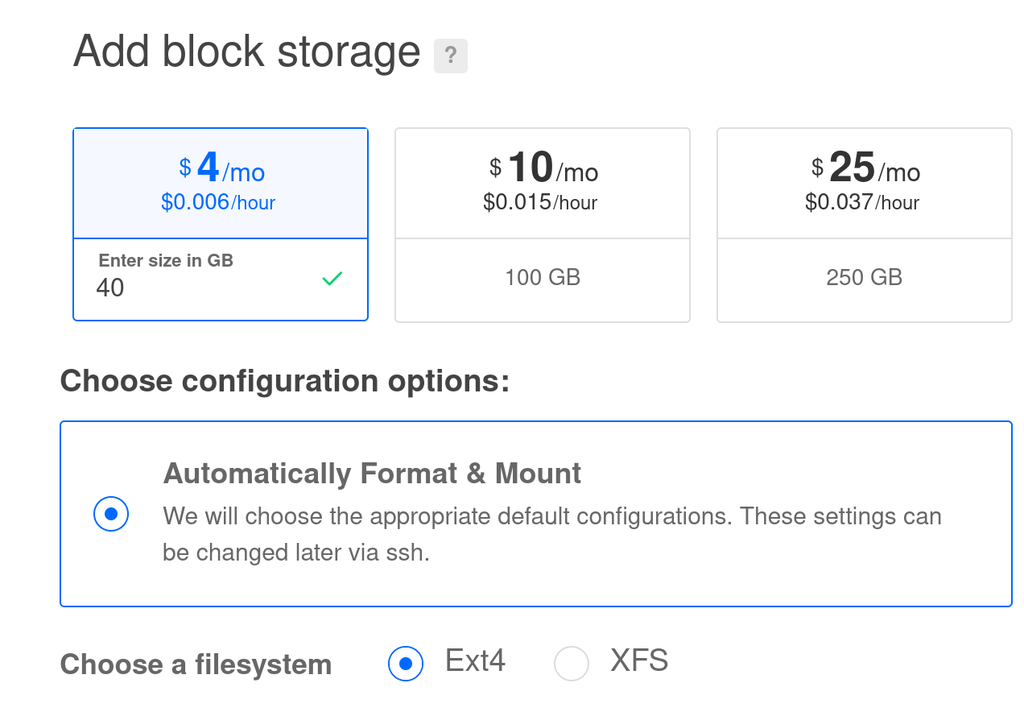

One of the goals of my course is to get the students “over the hump” of dealing with confusing Unixy stuff and thus I make everyone use ssh keys where appropriate. Here is one such case.

Since modern versions of Windows support ssh in Powershell, the instructions for generating keys are more or less the same on any platform. In your terminal of choice:

```
[toups@meso digital-ocean]$ ssh-keygen
Generating public/private rsa key pair.
Enter file in which to save the key (/home/toups/.ssh/id_rsa): ./digital-ocean-tutorial
Enter passphrase (empty for no passphrase):
Enter same passphrase again:
Your identification has been saved in ./digital-ocean-tutorial
Your public key has been saved in ./digital-ocean-tutorial.pub
The key fingerprint is:
SHA256:******************************************* toups@meso
The key's randomart image is:
+---[RSA 3072]----+
|*****************|
|*****************|
|*****************|
|*****************|
|*****************|
|*****************|
|*****************|
|*****************|
|*****************|
+----[SHA256]-----+
```

The hand waving explanation for what an ssh key pair goes like this:

Its a pair of numbers: a public one and a private one. If I have the private one and you have the public one, I can prove to you I have the private one without giving it to you. We’re going to upload our public key (which we can pass around willy nilly, which is why its called public) and then, whenever we want to connect to our server, we can prove its us using the private key, which we never share with anyone.

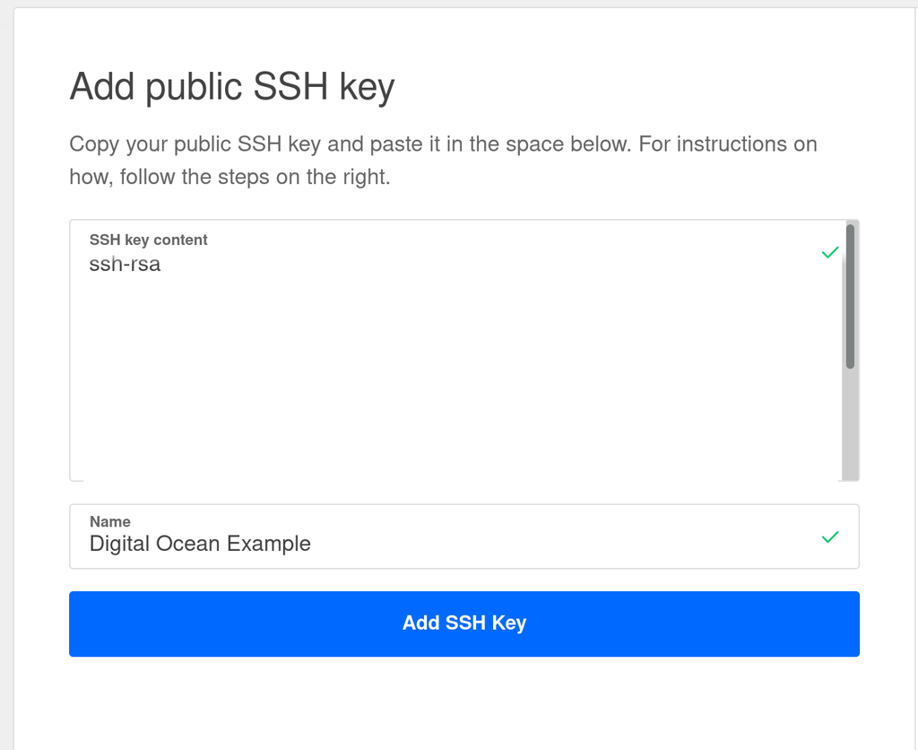

Finally, let’s add a tag to our VM. This is going to make it easier to understand billing if life ever gets complicated and we can also use the tag to enforce some firewall rules (see below).

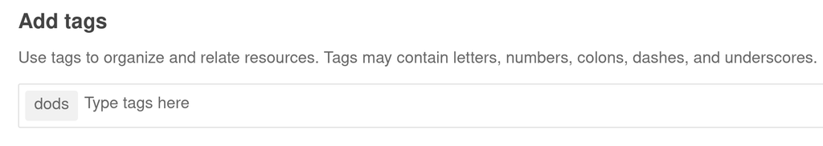

I’ve used a tag “dods” for “Digital Ocean Data Science.”

We’ll just use the default options for everything else and click “Create Droplet.”

[figure not shown]

Now that we’ve got root access to our machine we’re going to go ahead and do a little security work just to make our lives a little safer. Right now anyone can *try* to ssh into our machine. If we’re silly enough to put our private key somewhere people can see it, they can get in, too.

To make things just a little more secure, we’d like to set up our server to only respond to requests from our IP address. This reduces the attack surface of our machine.

We can do this in a few ways, but DO provides something called a “Cloud Firewall” which we can create and modify via DO’s web interface. This has the benefit that if we have to connect to our machine from a new IP address, we can just log in to DO and modify our rules from anywhere.

Use a convenient website like [ipchicken](https://ipchicken.com/) to find your IP address and put it in the Inbound Rules section of the page next to ssh. Delete the other two options to prevent other traffic from talking to your server. This isn’t perfect security, but combined with our ssh key we should be a relatively thin target.

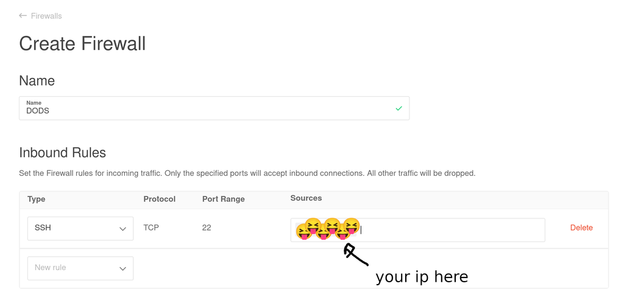

# HIT ME

[figure not shown]

I have a confession to make: I’m a console cowboy. A lot of data science tutorials are all about Jupyter or RStudio, but the fact is I do all my data science and just about most everything else from Emacs. I encourage students to get comfortable on the command line, since otherwise graphical user interfaces will form a ceiling for their career. The justification for this idea is that data scientists need at least two things to succeed: data and the means to get their results in front of other people. If a data scientist has broad technical skills they can do both of these things without relying on other technical experts. Getting comfortable with the Unix command line is the seed for those other technical skills.

So let’s ssh to our machine.

I’m delighted that on new versions of Windows powershell supports the ssh command right out of the box, so the instructions for connecting to our Droplet are pretty uniform:

1. Go to the networking tab of your droplet and get its public IP address.
2. In a terminal:

```
ssh-agent add digital-ocean-tutorial # add your private key to the
#current ssh-agent
ssh root@<your-machine's-ip>
```

If all is well then you should be greeted with a terminal on your machine. In the olden days we’d began the lugubrious process of setting up this machine for whatever we were going to do with it. But today we’re just going to install Docker.

If you aren’t familiar with system configuration, it can be hard to understand what Docker is good for but its not too hard to explain. When we do Data Science we depend on tools like Programming Languages (R, Python) and libraries associated with those languages. We may depend on other things more subtle (for example the way a particular operating system handles time). It can be a lot of work to set up a computer to support doing a particular data science project, and not every project needs the same set of libraries. In fact, some libraries or other systems may have trouble coexisting with one another on the same machine.

In the past people would just try their best to get a useful environment going and maybe they would try to document how they did it so other people could also use their work. Most of the time this was done poorly, and doing it right required quite a lot of expertise which isn’t easy to come by.

Docker is a tool which lets you describe an environment for doing work in a sort of fixed format (a Dockerfile). Given this file, Docker can recreate any particular system configuration you can make happen (and do it repeatedly). Once these little systems are created, you connect to them and do your work, comfortable in the more or less accurate belief that you can easily reproduce your environment.

An added benefit is that you can maintain many small environments for many different projects, making taming complex dependencies much easier. Even within one project, different steps might require different environments, which you can also wrangle with Docker.

For the working software person, Docker has a host of other benefits, but for Data Scientists, these flexible, reproducible, shareable environments are extremely useful.

# Installing Docker

Our Droplet is running Ubuntu. We’re just going to follow the instructions from Docker for [installation on that operating system](https://docs.docker.com/engine/install/ubuntu/).

```
apt-get update

apt-get install \
    ca-certificates \
    curl \
    gnupg \
    lsb-release

curl -fsSL https://download.docker.com/linux/ubuntu/gpg | sudo gpg --dearmor -o /usr/share/keyrings/docker-archive-keyring.gpg

echo \
  "deb [arch=$(dpkg --print-architecture) signed-by=/usr/share/keyrings/docker-archive-keyring.gpg] https://download.docker.com/linux/ubuntu \
  $(lsb_release -cs) stable" | sudo tee /etc/apt/sources.list.d/docker.list > /dev/null

apt-get update
apt-get install docker-ce docker-ce-cli containerd.io
```

Note that since we’re running as root here we don’t need to prefix everything with “sudo”. “sudo” is the way a non-root user asks to run things with root-like permissions.

Speaking of which, let’s create a user so we don’t have to always be running as root. This isn’t so much for security purposes as it is to just put some guard rails on us.

```
adduser dods
usermod -aG sudo dods
usermod -aG docker dods
```

This will let us run as the dods user like so:

```
su - dods
```

Now we can muck around without causing too much trouble if we make a mistake. Because we’ve added the dods user to the docker group we can still run docker as dods.

Its probably best for us to always just ssh directly to this machine so let’s copy our ssh configuration over to the dods user like this

```
sudo rsync --archive --chown=dods:dods ~/.ssh /home/dods/
```

At this point let’s log out and log-back in via ssh as the dods user.

(I always log out by typing CTRL-D but you can also say `exit`).

```
[toups@meso digital-ocean]$ ssh dods@159.223.157.***
Welcome to Ubuntu 20.04.3 LTS (GNU/Linux 5.4.0-96-generic x86_64)

 * Documentation:  https://help.ubuntu.com
 * Management:     https://landscape.canonical.com
 * Support:        https://ubuntu.com/advantage

  System information as of Thu Feb  3 15:51:39 UTC 2022

  System load:  0.08               Users logged in:          0
  Usage of /:   10.8% of 24.06GB   IPv4 address for docker0: 172.17.0.1
  Memory usage: 25%                IPv4 address for eth0:    159.223.157.***
  Swap usage:   0%                 IPv4 address for eth0:    10.10.0.5
  Processes:    106                IPv4 address for eth1:    10.116.0.2

9 updates can be applied immediately.
8 of these updates are standard security updates.
To see these additional updates run: apt list --upgradable


Last login: Thu Feb  3 15:48:06 2022 from 152.23.*
dods@ubuntu-s-1vcpu-1gb-nyc1-01:~$
```

Ok. Thats all we’re going to do with the underlying operating system here. Let’s just go ahead and start our R Studio Docker image.

```
docker run -d -p 8787:8787 -e PASSWORD=<type a password here> rocker/verse
```

That will start a basic rocker/verse server in the background.

Its worth saying a thing or two about the arguments we just passed docker. You can learn all about them from docker’s documentation. But the important thing to think about at this very moment is the `-p` argument, which tells docker how to map ports “outside” the container to ports “inside” the container. What `-p 8787:8787` means is “connect anyone trying to connect to the port 8787 *outside* the container to the port 8787 *inside* the container.”

Whe we started Docker scripts *inside* the container started an Rstudio server on port 8787. The `-p` argument just tells Docker we want to be able to access that server via 8787 on our machine.

Now that we’ve started our Docker container, the RStudio Server is waiting for us to talk to port 8787 on our Digital Ocean droplet. Just one problem, though:

Our Firewall doesn’t allow connections on port 8787. We could open that port up, but its probably safer to create a tunnel with SSH. Log out and log back in one more time, but like this:

```
ssh dods@159.223.157.*** -L 8787 localhost 8787
```

Now if you direct your browser to `localhost:8787` you will connect to RStudio running on your Droplet.

[figure not shown]

We have just a few more steps do do before we can focus entirely on Data Science.

# Our Workspace

How we proceed from here probably depends somewhat on our personal style and what we want to accomplish, but here is how I’d do it.

1. Log in to our VM and create a project directory

```
mkdir comic-data
cd comic-data
git init
```

2. Create a README.md

```
Superhero Power Analysis
========================

This repository will analyze the distribution of super powers among DC
Comics Characters.
```

3. Create a Dockerfile:

```
FROM rocker/verse
```

4. Create a “start-dev-env.sh” script:

```
#!/bin/bash

RANDOM_PW=$(head -1 <(fold -w 20  <(tr -dc 'a-zA-Z0-9' < /dev/urandom)))

docker build . -t dods
docker run --rm --name dods -e PASSWORD=$RANDOM_PW -p 8787:8787 -v $(pwd):/home/rstudio/ -t -d dods

echo Your password is $RANDOM_PW
echo Visit here: https://$(curl ifconfig.me/ip)
```

And then finally make our first commit:

```
git commit -m "Initial Commit!"
```

Now, whenever we’re ready to work, we can just ssh into our machine and run

```
bash start-dev-env.sh
```

And log in with username rstudio and the randomly generated password.

In the next tutorial we’ll build a web scraper and do some data analysis.